# Geoduck Research Project Report

Olivia

2023-05-12

## Project Goals

- annotate geoduck transcriptome
- annotate geoduck tissue transcriptome (gonad, ctenidia, heart, juvenile, larvae)
- add comparative species analysis with Mercenaria and Manila transcriptomes against geoduck transcriptome
- make heatmaps to visualize overexpressed and underexpressed genes
- add comoparative genome analysis with Mercenaria, Manila, Quadrangularis, Marissincia, and Solida clams

## What is a Geoduck?

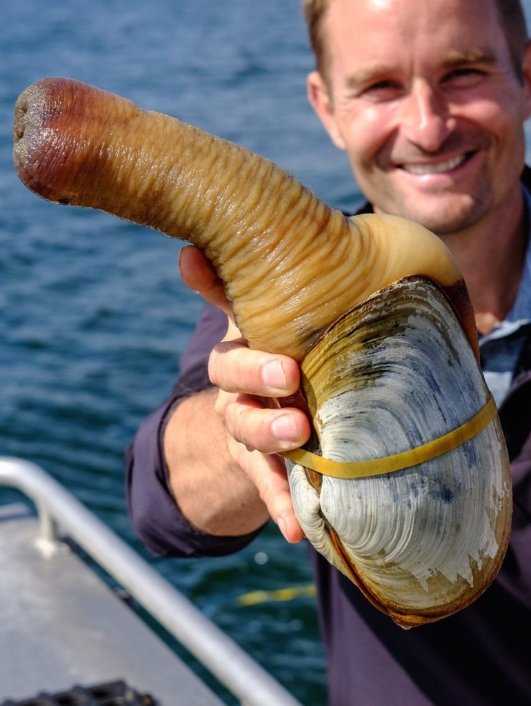

## Load Geoduck Transcriptome

```r
salmonMatrix<-read.table(file="https://raw.githubusercontent.com/sr320/paper-geoduck-gene-exp/main/data/salmon.merged.gene_tpm.tsv", header=TRUE, sep = '\t')
names(salmonMatrix)[1]<-"target_id"
names(salmonMatrix)[2]<-"gene"

goslims<-read.csv(file="https://raw.githubusercontent.com/RobertsLab/code/master/r_projects/sam/20230328-pgen-gene_annotation-update/outputs/02-goslim-mapping/20230329-pgen-annotations-SwissProt-GO-BP_GOslim.tab", header=TRUE, sep = '\t')

### <b>
pgenerosa_simple_goslims<-salmonMatrix %>%
  left_join(goslims, by=c("gene"))
### </b>

knitr::kable(head(pgenerosa_simple_goslims[1:5, 1:5]), "simple")
```

| target_id | gene | ctenidia | gonad | heart |
| --- | --- | --- | --- | --- |
| PGEN_.00g000010 | PGEN_.00g000010 | 0.000000 | 0.000000 | 0.000000 |
| PGEN_.00g000020 | PGEN_.00g000020 | 0.000000 | 0.000000 | 0.000000 |
| PGEN_.00g000030 | PGEN_.00g000030 | 0.225494 | 0.000000 | 0.000000 |
| PGEN_.00g000040 | PGEN_.00g000040 | 0.565506 | 0.000000 | 0.254843 |
| PGEN_.00g000050 | PGEN_.00g000050 | 0.508251 | 4.745168 | 0.228272 |

```r
#kable(head(pgenerosa_simple_goslims, n = 5))
#kable(pgenerosa_simple_goslims[1:5,], caption = "Pgenerosa Transcriptome")
```

```
##         target_id            gene ctenidia    gonad    heart juvenile   larvae
## 1 PGEN_.00g000010 PGEN_.00g000010 0.000000 0.000000 0.000000 4.851851 3.423667
## 2 PGEN_.00g000020 PGEN_.00g000020 0.000000 0.000000 0.000000 0.840164 0.370266
## 3 PGEN_.00g000030 PGEN_.00g000030 0.225494 0.000000 0.000000 0.069598 0.052545
## 4 PGEN_.00g000040 PGEN_.00g000040 0.565506 0.000000 0.254843 0.376364 1.131114
## 5 PGEN_.00g000050 PGEN_.00g000050 0.508251 4.745168 0.228272 0.182728 1.117655
## 6 PGEN_.00g000060 PGEN_.00g000060 6.490179 0.000000 0.000000 6.742646 5.936612
```

```
##         target_id            gene   tissue      tpm
## 1 PGEN_.00g000010 PGEN_.00g000010 ctenidia 0.000000
## 2 PGEN_.00g000020 PGEN_.00g000020 ctenidia 0.000000
## 3 PGEN_.00g000030 PGEN_.00g000030 ctenidia 0.225494
## 4 PGEN_.00g000040 PGEN_.00g000040 ctenidia 0.565506
## 5 PGEN_.00g000050 PGEN_.00g000050 ctenidia 0.508251
## 6 PGEN_.00g000060 PGEN_.00g000060 ctenidia 6.490179
```

P.generosa long format

| target_id | gene | tissue | tpm | binary | accessions |
| --- | --- | --- | --- | --- | --- |
| PGEN_.00g000010 | PGEN_.00g000010 | ctenidia | 0.000000 | 0 | Q86IC9;Q552T5 |
| PGEN_.00g000020 | PGEN_.00g000020 | ctenidia | 0.000000 | 0 | P04177 |
| PGEN_.00g000030 | PGEN_.00g000030 | ctenidia | 0.225494 | 1 | NA |
| PGEN_.00g000040 | PGEN_.00g000040 | ctenidia | 0.565506 | 1 | NA |
| PGEN_.00g000050 | PGEN_.00g000050 | ctenidia | 0.508251 | 1 | Q8L840;O04092;Q9FT71 |
| PGEN_.00g000060 | PGEN_.00g000060 | ctenidia | 6.490179 | 1 | Q61043;A0A1Y7VJL5;B2RQ73;B7ZMZ9;E9Q488;E9Q4S3;Q674R4;Q6ZPM7 |

## Break cells by semi-colon and return only distinct values

```r
#break cells and reform with unique values only
distinct_goslims <- pgenerosa_simple_goslims %>%
  ### <b>
  mutate(Term_unique = lapply(strsplit(as.character(Term), ";"), function(Term_unique) paste0(unique(Term_unique), collapse = ";")))  %>% distinct(Term_unique, .keep_all = TRUE) %>%
  mutate(GOslim_unique = lapply(strsplit(as.character(GOslim),";"),function(GOslim_unique) paste0(unique(GOslim_unique), collapse = ";"))) %>%
  distinct(GOslim_unique, .keep_all = TRUE)
### </b>

knitr::kable(head(distinct_goslims[1:5, 1:5]), "simple")
```

| target_id | gene | ctenidia | gonad | heart |
| --- | --- | --- | --- | --- |
| PGEN_.00g000010 | PGEN_.00g000010 | 0.000000 | 0.000000 | 0.000000 |
| PGEN_.00g000020 | PGEN_.00g000020 | 0.000000 | 0.000000 | 0.000000 |
| PGEN_.00g000050 | PGEN_.00g000050 | 0.508251 | 4.745168 | 0.228272 |
| PGEN_.00g000060 | PGEN_.00g000060 | 6.490179 | 0.000000 | 0.000000 |
| PGEN_.00g000080 | PGEN_.00g000080 | 0.000000 | 0.000000 | 0.119488 |

## Get GOterm counts

```r
#count top GOterms
tissue_goslims <- pgenerosa_long %>%
    group_by(tissue) %>%
  ### <b>
  filter(binary == 1) %>%
  ### </b>
  mutate(Term_unique = lapply(strsplit(as.character(Term), ";"), function(Term_unique) paste0(unique(Term_unique), collapse = ";"))) %>%
  distinct(Term_unique, .keep_all = TRUE) %>%
  filter(!is.na(Term_unique)) %>%
  separate_rows(Term_unique, sep = ";") %>%
  mutate(Term_unique = trimws(Term_unique)) %>%
  count(Term_unique, tissue, sort = TRUE)

kable(tissue_goslims[1:5,], caption="GOterms by tissue")
```

GOterms by tissue

| tissue | Term_unique | n |
| --- | --- | --- |
| juvenile | anatomical structure development | 1817 |
| larvae | anatomical structure development | 1743 |
| heart | anatomical structure development | 1678 |
| ctenidia | anatomical structure development | 1661 |
| juvenile | signaling | 1572 |

## SPECIES

- download blast from Mercenaria or Manila Clams against Pgenerosa db

| gene | Scaffold | Mercenaria_gene | V3 | V4 |
| --- | --- | --- | --- | --- |
| PGEN_.00g000040 | Scaffold_01:55792-67546 | XM_045314054.2 | 84.706 | 170 |
| PGEN_.00g000050 | Scaffold_01:67586-69113 | XM_053546612.1 | 83.056 | 602 |
| PGEN_.00g000060 | Scaffold_01:70713-81099 | XM_053526799.1 | 75.616 | 406 |
| PGEN_.00g000270 | Scaffold_01:344820-379444 | XM_053526799.1 | 76.190 | 609 |
| PGEN_.00g000280 | Scaffold_01:402378-436712 | XR_008368031.1 | 83.088 | 136 |

## ex) Annotated Mercenaria Transcriptome

```r
#join clam transcriptome with goslims
Manila_Pgen_goslims <- Manila_Pgen_new %>%
left_join(goslims, by=c("gene"))
Pgen_Manila_goslims <- Pgen_Manila_new %>%
  left_join(goslims, by=c("gene"))
Mercenaria_Pgen_goslims<- Mercenaria_Pgen_new %>%
left_join(goslims, by=c("gene")) #6521
### <b>
Pgen_Mercenaria_goslims<- Pgen_Mercenaria_new %>%
left_join(goslims, by=c("gene")) #5099
### </b>
knitr::kable(head(Pgen_Mercenaria_goslims[1:5, 1:5]), "simple",  caption="annotated Mercenaria Transcriptome")
```

annotated Mercenaria Transcriptome

| gene | Scaffold | Mercenaria_gene | V3 | V4 |
| --- | --- | --- | --- | --- |
| PGEN_.00g000040 | Scaffold_01:55792-67546 | XM_045314054.2 | 84.706 | 170 |
| PGEN_.00g000050 | Scaffold_01:67586-69113 | XM_053546612.1 | 83.056 | 602 |
| PGEN_.00g000060 | Scaffold_01:70713-81099 | XM_053526799.1 | 75.616 | 406 |
| PGEN_.00g000270 | Scaffold_01:344820-379444 | XM_053526799.1 | 76.190 | 609 |
| PGEN_.00g000280 | Scaffold_01:402378-436712 | XR_008368031.1 | 83.088 | 136 |

## View GOterm counts by Species

P. generosa

| Term_unique | n |
| --- | --- |
| anatomical structure development | 1853 |
| signaling | 1603 |
| cell differentiation | 1281 |
| DNA-templated transcription | 741 |
| regulation of DNA-templated transcription | 678 |

## GOterm counts for all Pgenerosa genes

```r
knitr::kable(term_count_best[1:10,], caption="GOterms count, removing duplicates")
```

GOterms count, removing duplicates

| transcriptome | Term_unique | n |
| --- | --- | --- |
| Pgenerosa | anatomical structure development | 1853 |
| Pgenerosa | signaling | 1603 |
| Pgenerosa | cell differentiation | 1281 |
| Pgenerosa | DNA-templated transcription | 741 |
| Pgenerosa | regulation of DNA-templated transcription | 678 |
| Pgenerosa | immune system process | 670 |
| Pgenerosa | programmed cell death | 600 |
| Pgenerosa | cell motility | 595 |
| Pgenerosa | reproductive process | 536 |
| Pgenerosa | cytoskeleton organization | 516 |

Total Terms per Species

| transcriptome | total_n |
| --- | --- |
| Manila | 1235 |
| Manila_r | 1390 |
| Mercenaria | 2198 |
| Mercenaria_r | 7027 |
| Pgenerosa | 17611 |
| NA | NA |
| NA | NA |

Species Normalized by Pgenerosa Transcriptome

| transcriptome | Term_unique | n_species | n_divided | n_Pgen |
| --- | --- | --- | --- | --- |
| Manila | anatomical structure development | 129 | 0.1044534 | 1853 |
| Manila | signaling | 113 | 0.0914980 | 1603 |
| Manila | cell differentiation | 86 | 0.0696356 | 1281 |
| Manila | cytoskeleton organization | 65 | 0.0526316 | 516 |
| Manila | DNA-templated transcription | 51 | 0.0412955 | 741 |

## Normalize Species by Pgenerosa transcriptome

```r
### <b>
filtered_data1 <- term_count_best %>%
  filter(transcriptome %in% c("Mercenaria_r", "Manila", "Mercenaria", "Manila_r")) %>%
  mutate(n_divided = case_when(
                               transcriptome == "Manila" ~ n/1235,
                               transcriptome == "Manila_r" ~ n/1390,
                               transcriptome == "Mercenaria" ~ n/2198,
                               transcriptome == "Mercenaria_r" ~ n/7027))
### </b>

knitr::kable(species_normal[1:5, 1:5],caption="Species Normalized by Pgenerosa Transcriptome")
```

Species Normalized by Pgenerosa Transcriptome

| transcriptome | Term_unique | n_species | n_divided | n_Pgen |
| --- | --- | --- | --- | --- |
| Manila | anatomical structure development | 129 | 0.1044534 | 1853 |
| Manila | signaling | 113 | 0.0914980 | 1603 |
| Manila | cell differentiation | 86 | 0.0696356 | 1281 |
| Manila | cytoskeleton organization | 65 | 0.0526316 | 516 |
| Manila | DNA-templated transcription | 51 | 0.0412955 | 741 |

# Download Clam Genomes

## load genomes from blast output

```r
Mercenaria_genome<-read.csv(file="https://gannet.fish.washington.edu/gigas/data/p.generosa/Pgenerosa_Mercenaria_db_genome_blastn.tab", sep = '\t', header = FALSE)

Quadrangularis_genome<-read.csv(file="https://gannet.fish.washington.edu/gigas/data/p.generosa/Pgenerosa_quadrangularis_db_genome_blastn.tab", sep = '\t', header = FALSE)

Manila_genome<-read.csv(file="https://gannet.fish.washington.edu/gigas/data/p.generosa/Pgenerosa_manila_db_genome_blastn.tab", sep = '\t', header = FALSE)

Marissincia_genome<-read.csv(file="https://gannet.fish.washington.edu/gigas/data/p.generosa/Pgenerosa_marissinsa_db_genome_blastn.tab", sep = '\t', header = FALSE)

Solida_genome<-read.csv(file="https://gannet.fish.washington.edu/gigas/data/p.generosa/solida_db_genome_blastn.tab", sep = '\t', header = FALSE)
```

### get summary data for genomes

```r
#Mercenaria
Mercenaria_new <- separate(Mercenaria_genome, V1, into = c("gene", "Scaffold"), sep = "::")
names(Mercenaria_new)[1]<-"gene"
names(Mercenaria_new)[12]<-"e-value"

Mercenaria_summary <- Mercenaria_new %>%
  mutate(Marissincia_genes = lapply(strsplit(as.character(V2), ";"), function(Marissincia_genes) paste0(unique(Marissincia_genes), collapse = ";"))) %>%
  distinct(Marissincia_genes, .keep_all = TRUE)

#Quadrangularis
Quadrangularis_new <- separate(Quadrangularis_genome, V1, into = c("gene", "Scaffold"), sep = "::")
names(Quadrangularis_new)[1]<-"gene"
names(Quadrangularis_new)[12]<-"e-value"

Quadrangularis_summary <- Quadrangularis_new %>%
  mutate(genes = lapply(strsplit(as.character(V2), ";"), function(genes) paste0(unique(genes), collapse = ";"))) %>%
  distinct(genes, .keep_all = TRUE)

#Manila
Manila_new <- separate(Manila_genome, V1, into = c("gene", "Scaffold"), sep = "::")
names(Manila_new)[1]<-"gene"
names(Manila_new)[12]<-"e-value"

Manila_summary <- Manila_new%>%
  mutate(genes = lapply(strsplit(as.character(V2), ";"), function(genes) paste0(unique(genes), collapse = ";"))) %>%
  distinct(genes, .keep_all = TRUE)

#Marissincia
Marissincia_new <- separate(Marissincia_genome, V1, into = c("gene", "Scaffold"), sep = "::")
names(Marissincia_new)[1]<-"gene"
names(Marissincia_new)[12]<-"e-value"

Marissincia_summary <- Marissincia_new %>%
  mutate(Marissincia_genes = lapply(strsplit(as.character(V2), ";"), function(Marissincia_genes) paste0(unique(Marissincia_genes), collapse = ";"))) %>%
  distinct(Marissincia_genes, .keep_all = TRUE)

#Solida
Solida_new <- separate(Solida_genome, V1, into = c("gene", "Scaffold"), sep = "::")
names(Solida_new)[1]<-"gene"
names(Solida_new)[12]<-"e-value"

Solida_summary <- Solida_new%>%
  mutate(genes = lapply(strsplit(as.character(V2), ";"), function(genes) paste0(unique(genes), collapse = ";"))) %>%
  distinct(genes, .keep_all = TRUE)

knitr::kable(head(Solida_summary[1:5, 1:5]), "simple")
```

| gene | Scaffold | V2 | V3 | V4 |
| --- | --- | --- | --- | --- |
| PGEN_.00g000060 | Scaffold_01:70713-81099 | OX365947.1 | 74.279 | 416 |
| PGEN_.00g000270 | Scaffold_01:344820-379444 | OX365949.1 | 75.163 | 306 |
| PGEN_.00g000320 | Scaffold_01:571666-599482 | OX365950.1 | 79.545 | 220 |
| PGEN_.00g000670 | Scaffold_01:1389639-1400328 | OX365948.1 | 87.857 | 140 |
| PGEN_.00g001410 | Scaffold_01:2961919-2993436 | OX365952.1 | 79.126 | 206 |

## make tables for clam genomes

```r
clam_genomes<-bind_rows(lst(Solida_new, Marissincia_new, Mercenaria_new, Manila_new, Quadrangularis_new), .id = "clam")

knitr::kable(head(clam_genomes[1:5, 1:5]), "simple")
```

| clam | gene | Scaffold | V2 | V3 |
| --- | --- | --- | --- | --- |
| Solida_new | PGEN_.00g000060 | Scaffold_01:70713-81099 | OX365947.1 | 74.279 |
| Solida_new | PGEN_.00g000270 | Scaffold_01:344820-379444 | OX365949.1 | 75.163 |
| Solida_new | PGEN_.00g000300 | Scaffold_01:503707-557915 | OX365947.1 | 83.648 |
| Solida_new | PGEN_.00g000320 | Scaffold_01:571666-599482 | OX365950.1 | 79.545 |
| Solida_new | PGEN_.00g000670 | Scaffold_01:1389639-1400328 | OX365948.1 | 87.857 |

## TISSUES

- gonad
- ctenidia
- heart
- juvenile
- larvae

Total Terms per Tissue(s)

| tissue | total_n |
| --- | --- |
| ctenidia | 15911 |
| gonad | 14715 |
| heart | 16021 |
| juvenile | 17277 |
| larvae | 16632 |
| NA | NA |

## Normalized Tissue Data

```r
filtered_data <- tissue_goslims %>%
  filter(tissue %in% c("ctenidia", "heart", "gonad", "larvae", "juvenile")) %>%
  ### <b>
  mutate(n_divided = case_when(tissue == "ctenidia" ~ n/15911,
                               tissue == "heart" ~ n/16021,
                               tissue == "gonad" ~ n/14715,
                               tissue == "larvae" ~ n/16632,
                               tissue == "juvenile" ~ n/17277))
### </b>
kable(Tis_normal[1:7,])
```

| tissue | Term_unique | n_tissue | n_divided | n_Pgen | Pgen_normalized | normalized | log_scale |
| --- | --- | --- | --- | --- | --- | --- | --- |
| juvenile | anatomical structure development | 1817 | 0.1051687 | 1853 | 0.1052183 | 0.9995285 | -0.0004716 |
| larvae | anatomical structure development | 1743 | 0.1047980 | 1853 | 0.1052183 | 0.9960050 | -0.0040030 |
| heart | anatomical structure development | 1678 | 0.1047375 | 1853 | 0.1052183 | 0.9954305 | -0.0045800 |
| ctenidia | anatomical structure development | 1661 | 0.1043932 | 1853 | 0.1052183 | 0.9921578 | -0.0078731 |
| juvenile | signaling | 1572 | 0.0909880 | 1603 | 0.0910227 | 0.9996195 | -0.0003806 |
| gonad | anatomical structure development | 1524 | 0.1035678 | 1853 | 0.1052183 | 0.9843132 | -0.0158112 |
| larvae | signaling | 1501 | 0.0902477 | 1603 | 0.0910227 | 0.9914863 | -0.0085502 |

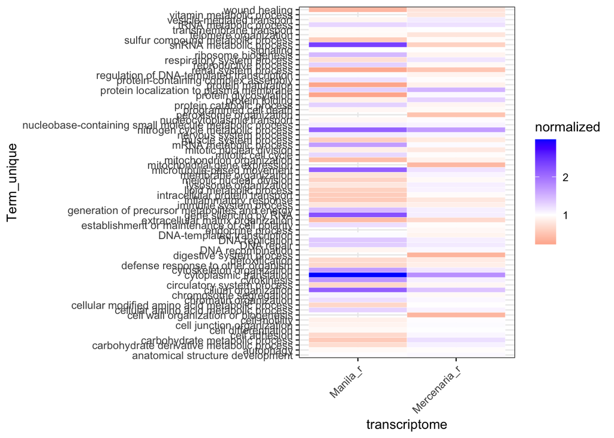

## Tissue Heatmap normalized by P. generosa transcriptome where white = 0.9

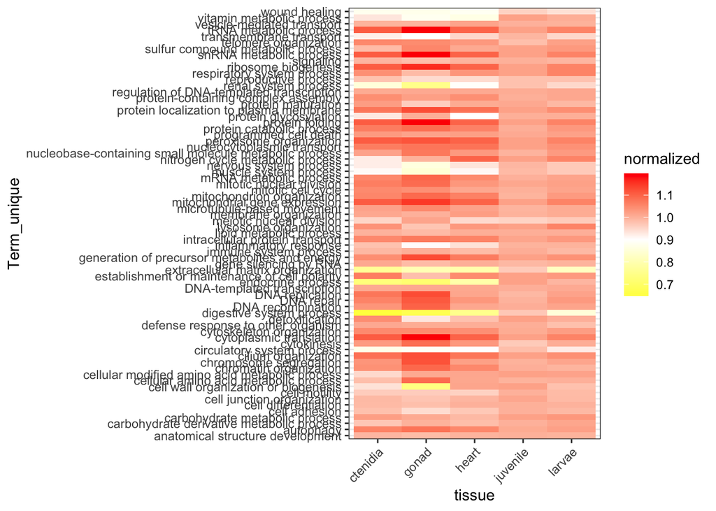

## Plan for the next couple weeks:

Week 1 - presented research at National Shellfish Association Meeting

Week 2 - Got COVID, started downloading clam transcriptomes

Week 3 - gather genes from each tissue type, build sh files for blasting manilla clam and mercenaria against pgen in Mox, Run stand blasts with Manilla, Pgen and Mercenaria build database for Manilla, Pgen and Mercenaria, start writing methods

Week 4 - dowload to raven the genomic and transctiptomic information for 6 clam species, find transcriptomes for introduction, break goslims into seperate columns, join blast tables with annotation tables

Week 5 - added new normalizing gene count column for heatmapping, finished writing draft 1 of results, working on methods, finish introduction

Week 6 - finish writing introduction/discussion for geoduck paper

Week 7 - address edits from Steven for CS work, run blast against other clam transcriptomes (step 8), make table for compairative clam analysis, update methods and results in geoduck paper

Week 8 -

Week 9 -

Week 10 - hopefully nothing, prepare for graduation!